# Session 6 Practice: Errors/error messages

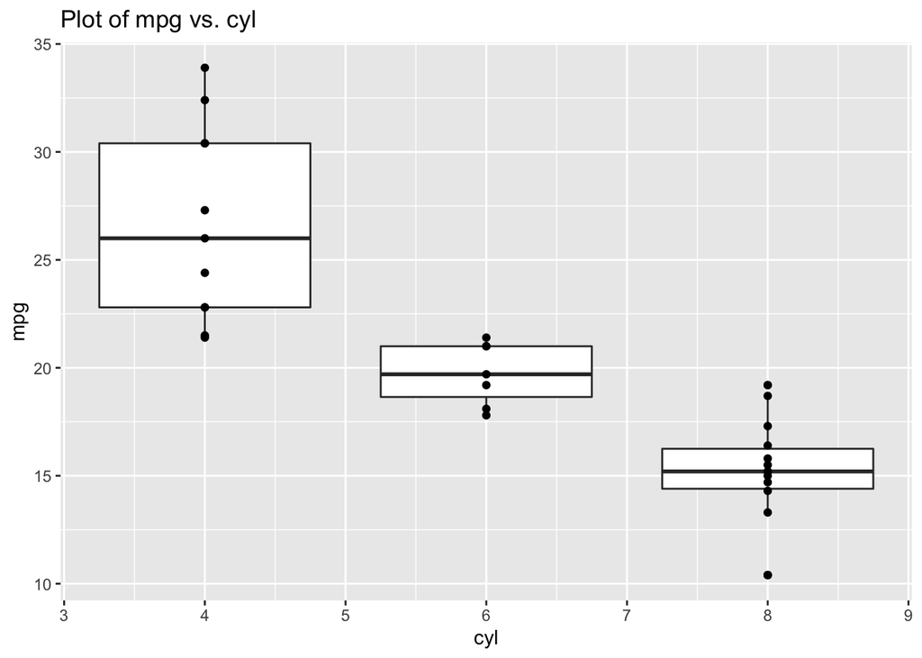

```r
ggplot(data = mtcars, aes(x = cyl, y = mpg, group = cyl)) +
    geom_boxplot() +
    geom_point() +
    labs(title = "Plot of mpg vs. cyl")
```

7. We want a scatterplot of `qsec` vs. `wt`, but we want all the points to be colored blue:

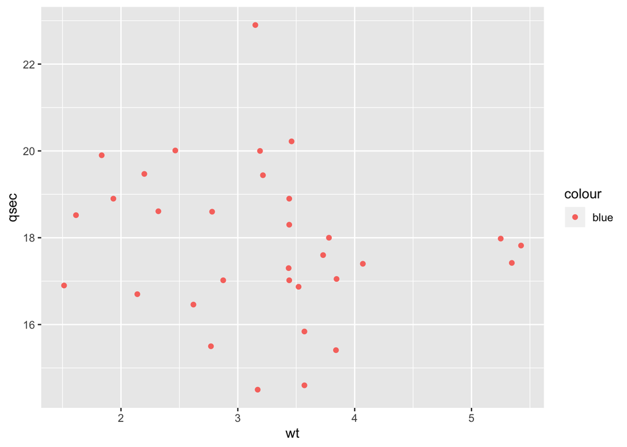

```r
ggplot(data = mtcars, aes(y = qsec, x = wt)) +
    geom_point(aes(col = "blue"))
```

If we want the color of the points NOT to be data-dependent, then it should not go into the `aes` call:

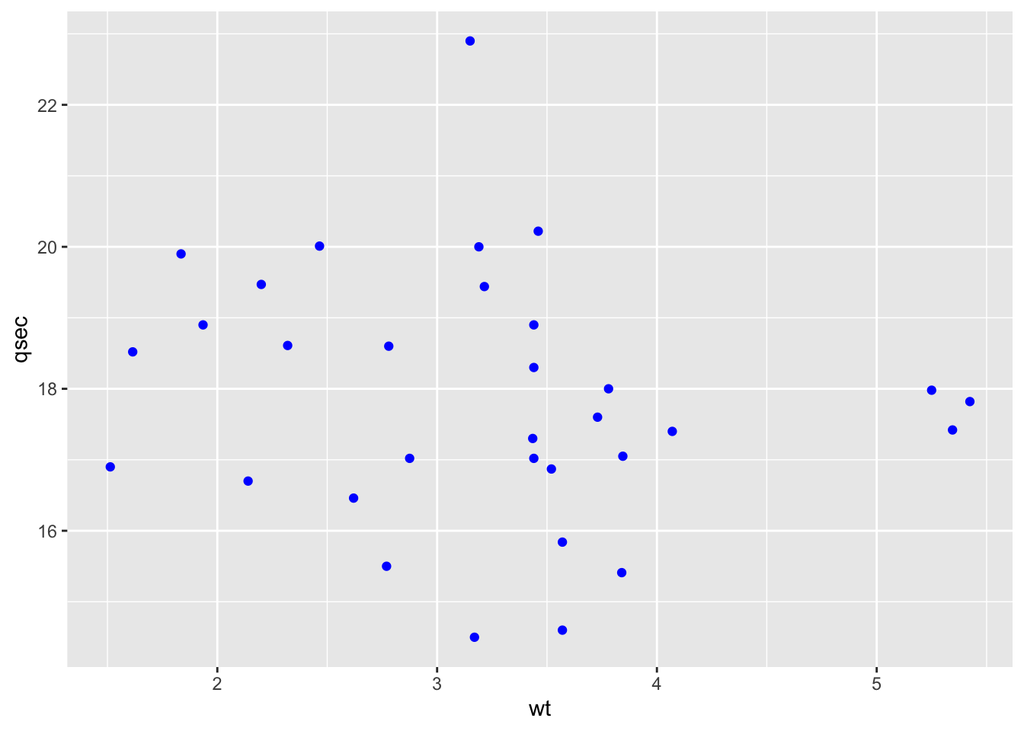

```r
ggplot(data = mtcars, aes(y = qsec, x = wt)) +
    geom_point(col = "blue")
```

8. We want to create a new column which is `miles per quart` and display the first 3 rows:

```r
mtcars %>% mutate(miles per quart = mpg / 4) %>% head(n = 3)
```

```
## Error: <text>:1:25: unexpected symbol
## 1: mtcars %>% mutate(miles per
##                             ^
```

If we want column names to have spaces, we need to surround the new column name with backticks:

```r
mtcars %>% mutate(`miles per quart` = mpg / 4) %>% head(n = 3)
```

```
##    mpg cyl disp  hp drat    wt  qsec vs am gear carb miles per quart
## 1 21.0   6  160 110 3.90 2.620 16.46  0  1    4    4            5.25
## 2 21.0   6  160 110 3.90 2.875 17.02  0  1    4    4            5.25
## 3 22.8   4  108  93 3.85 2.320 18.61  1  1    4    1            5.70
```

9. We want to compute the mean `mpg` for each value of `gear`:

```r
mtcars %>% group_by(gear) %>% summarize(mean = mean)
```

```
## Error: Column `mean` is of unsupported type function
```

We forgot to say that we should be taking the mean of `mpg`:

```r
mtcars %>% group_by(gear) %>% summarize(mean = mean(mpg))
```

```
## # A tibble: 3 x 2
##    gear  mean
##   <dbl> <dbl>
## 1     3  16.1
## 2     4  24.5
## 3     5  21.4
```

10. We want to compute the maximum `hp` and `disp` in the dataset:

```r
mtcars %>% summarize(max = max(hp, disp))
```

```
##   max
## 1 472
```

The code above looks for the single maximum across the 2 columns `hp` and `disp` and returns just that value. To compute the maximum in each column, we must have them in separate calls:

```r
mtcars %>% summarize(max_hp = max(hp),
                      max_disp = max(disp))
```

```
##   max_hp max_disp
## 1    335      472
```